# Gene Expression Analysis

Human Dermal Fibroblasts, neonatal (HDFn) | GSE32581 | Necroptosis, Ferroptosis & Pyroptosis

Mark Edward M. Gonzales[^1]

Dr. Anish M.S. Shrestha[^2]

## I. Preliminaries

### Loading libraries

```r
library("tidyverse")
library("tibble")
library("msigdbr")
library("ggplot2")
library("ensembldb")
library("purrr")
library("magrittr")
library("matrixStats")
library("dplyr")
library("grex")
library("gplots")
library("RColorBrewer")
library("illuminaHumanv4.db")
```

### Constants

```r
DATA_DIR <- "../data/public/GEO/HDFn/"
```

## Loading the Expression Data

The expression data are taken from this study: https://www.ncbi.nlm.nih.gov/geo/query/acc.cgi?acc=GSE32581

```r
hdfn.expression <- read.delim(paste0(DATA_DIR, "GSE32581-hdfn.tsv"), as.is = TRUE, header = TRUE, row.names = 1)
hdfn.expression <- rownames_to_column(hdfn.expression, "ID_REF")
hdfn.expression <- hdfn.expression[c("ID_REF", "VALUE")]
hdfn.expression
```

| ID_REF | VALUE |
| --- | --- |
| ILMN_1802380 | 793.35 |
| ILMN_1893287 | 119.75 |
| ILMN_3238331 | 99.03 |
| ILMN_1736104 | 101.60 |
| ILMN_1792389 | 145.59 |
| ILMN_1854015 | 201.22 |
| ILMN_3308818 | 92.51 |
| ILMN_1740305 | 136.87 |
| ILMN_3242405 | 111.76 |
| ILMN_1665168 | 121.24 |

[output cut: 990 more lines]

Map the Illumina probe IDs to Ensembl accessions.

```r
illumina_to_ensembl <- data.frame(gene_id = unlist(mget(x = hdfn.expression[["ID_REF"]], envir = illuminaHumanv4ENSEMBL)))
illumina_to_ensembl <- rownames_to_column(illumina_to_ensembl, "ID_REF")
illumina_to_ensembl
```

| ID_REF | gene_id |
| --- | --- |
| ILMN_1802380 | ENSG00000142599 |
| ILMN_1893287 | NA |
| ILMN_3238331 | NA |
| ILMN_1736104 | NA |
| ILMN_1792389 | ENSG00000141622 |
| ILMN_1854015 | NA |
| ILMN_3308818 | ENSG00000207653 |
| ILMN_1740305 | NA |
| ILMN_3242405 | ENSG00000277027 |
| ILMN_1665168 | NA |

[output cut: 990 more lines]

```r
hdfn.expression <- left_join(hdfn.expression, illumina_to_ensembl)
hdfn.expression
```

| ID_REF | VALUE | gene_id |
| --- | --- | --- |
| ILMN_1802380 | 793.35 | ENSG00000142599 |
| ILMN_1893287 | 119.75 | NA |
| ILMN_3238331 | 99.03 | NA |
| ILMN_1736104 | 101.60 | NA |
| ILMN_1792389 | 145.59 | ENSG00000141622 |
| ILMN_1854015 | 201.22 | NA |
| ILMN_3308818 | 92.51 | ENSG00000207653 |
| ILMN_1740305 | 136.87 | NA |
| ILMN_3242405 | 111.76 | ENSG00000277027 |
| ILMN_1665168 | 121.24 | NA |

[output cut: 990 more lines]

## Exploratory Data Analysis

We load the gene sets from RCDdb: https://pubmed.ncbi.nlm.nih.gov/39257527/

```r
RCDdb <- "../data/public/rcd-gene-list/RCDdb/"
```

### Necroptosis

Load the gene set.

```r
genes <- read.csv(paste0(RCDdb, "Necroptosis.csv"))
genes$gene_id <- cleanid(genes$gene_id)
genes <- distinct(genes, gene_id, .keep_all = TRUE)
genes <- subset(genes, gene_id != "")
genes
```

|  | deathtype | gene | description | gene_id | gene_biotype | pmid | comment |
| --- | --- | --- | --- | --- | --- | --- | --- |
| 1 | Necroptosis | GLUD1 | glutamate dehydrogenase 1 | ENSG00000148672 | protein_coding | 30029665 | The activation of GLUD1 led to the disruption of metabolic balance and cell death. Resibufogenin induces cell death dependent on necroptosis by activating RIP3 and phosphorylating mixed lineage kinase… |
| 2 | Necroptosis | ALOX15 | arachidonate 15-lipoxygenase | ENSG00000161905 | protein_coding | 29891910 | Necroptosis occurred in the skin in the absence of ALOX15. In addition, apoptosis markers were also upregulated in the dorsal skin of ALOX15 KO mice. ALOX15 plays a critical role in maintaining skin h… |
| 3 | Necroptosis | FTH1 | ferritin heavy chain 1 | ENSG00000167996 | protein_coding | 32984939 | Low concentrations of boron can promote cell proliferation and differentiation by inhibiting the expression of FTH1, reducing iron ion accumulation and ROS production in cells, and thereby reducing ce… |
| 4 | Necroptosis | CAPN1 | calpain 1 | ENSG00000014216 | protein_coding | 37168851 | CAPN1 activation has been demonstrated to degrade cytoskeleton proteins, vital enzymes, and mitochondrial membrane-related proteins, which may play a primary role in ischemia-induced neuronal injury, … |
| 5 | Necroptosis | CASP1 | caspase 1 | ENSG00000137752 | protein_coding | 36389690 | CASP1 is involved in the regulation of necroptosis. In this study, CASP1 was one of the three selected necroptosis-related genes used to construct a prognostic model and risk score system to predict t… |
| 6 | Necroptosis | BAX | BCL2 associated X, apoptosis regulator | ENSG00000087088 | protein_coding | 32768820 | Chlorpyrifos (CPF) could promote the expression of BAX mRNA and protein and induce apoptosis and necroptosis of L8824 cells. CPF could also activate the expression of genes related to the Necroptosis … |
| 7 | Necroptosis | BCL2 | BCL2 apoptosis regulator | ENSG00000171791 | protein_coding | 31634424 | Fisetin can reduce the expression of the anti-apoptotic protein BCL2 and increase the levels of pro-apoptotic proteins Bax, caspase-3, and PARP in HepG2 cells, inducing cell death through apoptosis pa… |
| 8 | Necroptosis | FADD | Fas associated via death domain | ENSG00000168040 | protein_coding | 36191211 | The absence of Caspase-8 or FADD can lead to spontaneous activation of RIPK3, phosphorylation of MLKL, and necroptosis.the proteolytic activity of the FADD/Caspase-8 complex can inhibit ZBP1-induced n… |
| 9 | Necroptosis | RIPK1 | receptor interacting serine/threonine kinase 1 | ENSG00000137275 | protein_coding | 27493188 | The absence of Optineurin leads to progressive dysmyelination and axonal degeneration in the central nervous system through the engagement of Necroptotic machinery, including RIPK1, RIPK3, and MLKL. I… |
| 10 | Necroptosis | TNF | tumor necrosis factor | ENSG00000232810 | protein_coding | 31221990 | TNF is one of the key factors in the formation of Necroptosis, inducing the formation of RIPK1 and RIPK3 Necrosome through TNFR1 in different cell types, which leads to the phosphorylation and oligome… |

[output cut: 73 more lines]

Get the normalized expression data for the genes in the gene set.

```r
tpm.df <- hdfn.expression %>% dplyr::filter(gene_id %in% genes$gene_id)
tpm.df <- left_join(tpm.df, genes %>% dplyr::select(gene_id, gene), by = c("gene_id" = "gene_id"))
tpm.df <- distinct(tpm.df, gene, .keep_all = TRUE)
rownames(tpm.df) <- tpm.df$gene
tpm.df <- subset(tpm.df, select = -c(gene_id, ID_REF, gene))
tpm.df <- tpm.df[order(row.names(tpm.df)), , drop = FALSE]
tpm.df
```

|  | VALUE |
| --- | --- |
| AIFM1 | 1148.72 |
| ALOX15 | 142.23 |
| BAX | 2331.55 |
| BCL2 | 94.30 |
| BID | 316.75 |
| BIRC2 | 950.75 |
| BIRC3 | 171.63 |
| CAMK2A | 56.70 |
| CAPN1 | 1451.47 |
| CAPN2 | 578.31 |

[output cut: 67 more lines]

Plot the results.

**NOTE: `VALUE` and `VALUE1` are the same. This is just a workaround since R’s `heatmap.2` requires the heatmap to have at least two columns.**

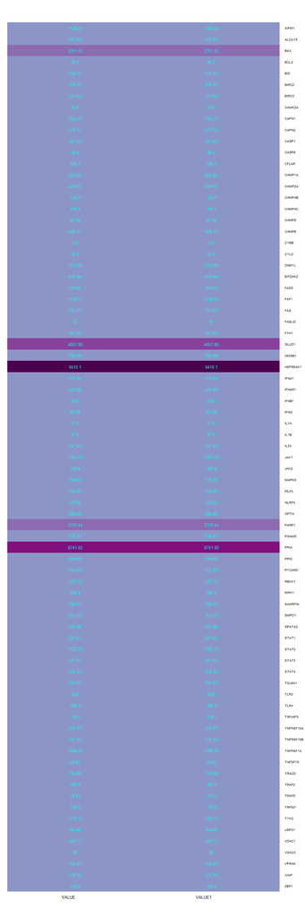

```r
tpm.df[["VALUE1"]] <- tpm.df[["VALUE"]]
tpm.matrix <- as.matrix(tpm.df)
heatmap.2(tpm.matrix,
  srtCol = 360,
  cellnote = tpm.matrix,
  dendrogram = "none", Colv = FALSE, Rowv = FALSE,
  col = brewer.pal(n = 9, name = "BuPu")[5:9], trace = "none", key = FALSE, lwid = c(0.1, 4), lhei = c(0.1, 4),
  cexCol = 1, cexRow = 0.75, symm = TRUE
)
```

### Ferroptosis

Load the gene set.

```r
genes <- read.csv(paste0(RCDdb, "Ferroptosis.csv"))
genes$gene_id <- cleanid(genes$gene_id)
genes <- distinct(genes, gene_id, .keep_all = TRUE)
genes <- subset(genes, gene_id != "")
genes
```

|  | deathtype | gene | description | gene_id | gene_biotype | pmid | comment |
| --- | --- | --- | --- | --- | --- | --- | --- |
| 1 | Ferroptosis | RPL8 | ribosomal protein L8 | ENSG00000161016 | protein_coding | 22632970 | Required in erastin-induced ferroptosis. Silencing of it conferred against erastin-induced ferroptosis. |
| 2 | Ferroptosis | IREB2 | iron responsive element binding protein 2 | ENSG00000136381 | protein_coding | 22632970 | Required in erastin-induced ferroptosis. Silencing of it conferred against erastin-induced ferroptosis. |
| 3 | Ferroptosis | ATP5MC3 | ATP synthase membrane subunit c locus 3 | ENSG00000154518 | protein_coding | 22632970 | Required in erastin-induced ferroptosis. Silencing of it conferred against erastin-induced ferroptosis. |
| 4 | Ferroptosis | CS | citrate synthase | ENSG00000062485 | protein_coding | 22632970 | Required in erastin-induced ferroptosis. Silencing of it conferred against erastin-induced ferroptosis. |
| 5 | Ferroptosis | EMC2 | ER membrane protein complex subunit 2 | ENSG00000104412 | protein_coding | 22632970 | Required in erastin-induced ferroptosis. Silencing of it conferred against erastin-induced ferroptosis. |
| 6 | Ferroptosis | ACSF2 | acyl-CoA synthetase family member 2 | ENSG00000167107 | protein_coding | 22632970 | Required in erastin-induced ferroptosis. Silencing of it conferred against erastin-induced ferroptosis. |
| 7 | Ferroptosis | NOX1 | NADPH oxidase 1 | ENSG00000007952 | protein_coding | 22632970 | Suppresses erastin-induced ferroptosis when inhibited by inhibitor. |
| 8 | Ferroptosis | CYBB | cytochrome b-245 beta chain | ENSG00000165168 | protein_coding | 22632970 | Suppresses erastin-induced ferroptosis when inhibited by inhibitor. |
| 9 | Ferroptosis | NOX3 | NADPH oxidase 3 | ENSG00000074771 | protein_coding | 22632970 | Suppresses erastin-induced ferroptosis when inhibited by inhibitor. |
| 10 | Ferroptosis | NOX4 | NADPH oxidase 4 | ENSG00000086991 | protein_coding | 22632970 | Suppresses erastin-induced ferroptosis when inhibited by inhibitor. |

[output cut: 539 more lines]

Get the normalized expression data for the genes in the gene set.

```r
tpm.df <- hdfn.expression %>% dplyr::filter(gene_id %in% genes$gene_id)
tpm.df <- left_join(tpm.df, genes %>% dplyr::select(gene_id, gene), by = c("gene_id" = "gene_id"))
tpm.df <- distinct(tpm.df, gene, .keep_all = TRUE)
rownames(tpm.df) <- tpm.df$gene
tpm.df <- subset(tpm.df, select = -c(gene_id, ID_REF, gene))
tpm.df <- tpm.df[order(row.names(tpm.df)), , drop = FALSE]
tpm.df
```

|  | VALUE |
| --- | --- |
| ABCB10 | 265.93 |
| ABCC5 | 66.20 |
| ABHD12 | 814.10 |
| ACADSB | 129.05 |
| ACO1 | 4384.57 |
| ACOT1 | 107.00 |
| ACSF2 | 156.12 |
| ACSL1 | 135.88 |
| ACSL3 | 3626.26 |
| ACSL4 | 155.08 |

[output cut: 453 more lines]

Plot the results.

**NOTE: `VALUE` and `VALUE1` are the same. This is just a workaround since R’s `heatmap.2` requires the heatmap to have at least two columns.**

[figure not shown]

```r
tpm.df[["VALUE1"]] <- tpm.df[["VALUE"]]
tpm.matrix <- as.matrix(tpm.df)
heatmap.2(tpm.matrix,
  srtCol = 360,
  cellnote = tpm.matrix,
  dendrogram = "none", Colv = FALSE, Rowv = FALSE,
  col = brewer.pal(n = 9, name = "BuPu")[5:9], trace = "none", key = FALSE, lwid = c(0.1, 4), lhei = c(0.1, 4),
  cexCol = 1, cexRow = 0.75, symm = TRUE
)
```

### Pyroptosis

Load the gene set.

```r
genes <- read.csv(paste0(RCDdb, "Pyroptosis.csv"))
genes$gene_id <- cleanid(genes$gene_id)
genes <- distinct(genes, gene_id, .keep_all = TRUE)
genes <- subset(genes, gene_id != "")
genes
```

|  | deathtype | gene | description | gene_id | gene_biotype | pmid | comment |
| --- | --- | --- | --- | --- | --- | --- | --- |
| 1 | Pyroptosis | BAK1 | BCL2 antagonist/killer 1 | ENSG00000030110 | protein_coding | 35439536 | BAK1 is a protein that promotes cell apoptosis. The protein level of BAK1 in cells treated with BPA is significantly higher than that in the control group. The action of YVAD clearly shows that caspas… |
| 2 | Pyroptosis | BAX | BCL2 associated X, apoptosis regulator | ENSG00000087088 | protein_coding | 32332857 | Chemotherapy-induced pyroptosis in cancer cells is mediated by BAK/BAX-caspase-3-GSDME signaling pathway. |
| 3 | Pyroptosis | CASP1 | caspase 1 | ENSG00000137752 | protein_coding | 34531375 | PRMT5 can regulate cell pyroptosis in multiple myeloma by inhibiting the expression of CASP1. When PRMT5 expression is interfered, the expression of CASP1 is upregulated, thus promoting pyroptosis of … |
| 4 | Pyroptosis | CASP3 | caspase 3 | ENSG00000164305 | protein_coding | 33133646 | When GSDME is highly expressed, chemotherapeutic drugs can induce CASP3-dependent Pyroptosis, thereby shrinking tumors.CASP3 is a key protein that induces apoptosis and inflammatory cell death, which … |
| 5 | Pyroptosis | CASP4 | caspase 4 | ENSG00000196954 | protein_coding | 32109412 | Site-specific autoprocessing of Caspase-4/11 generates a p10 product that binds with high affinity to the GSDMD-C domain, facilitating cleavage of GSDMD and inducing Pyroptosis. Crystal structures of … |
| 6 | Pyroptosis | CASP5 | caspase 5 | ENSG00000137757 | protein_coding | 32109412 | CASP5 can generate a p10 product that binds with high affinity to the GSDMD-C (inhibitory domain of gasdermin D), facilitating cleavage of GSDMD and inducing Pyroptosis through site-specific autoproce… |
| 7 | Pyroptosis | CASP6 | caspase 6 | ENSG00000138794 | protein_coding | 32298652 | CASP6 promotes pyroptosis induced by IAV infection and CASP6 deficiency reduces the number of cell deaths during IAV infection . In addition, CASP6 also participates in the activation of other cell de… |
| 8 | Pyroptosis | CASP8 | caspase 8 | ENSG00000064012 | protein_coding | 31748744 | The expression of enzymatically inactive CASP8(C362S) triggered the formation of ASC specks, activation of caspase-1 and secretion of IL-1\xa6\xc2, resulting in pyroptosis. |
| 9 | Pyroptosis | CASP9 | caspase 9 | ENSG00000132906 | protein_coding | 27174943 | CASP9 does not seem to be directly related to Necroptosis.Injection of a CAS-9 inhibitor significantly inhibits high level CASP-1 activity in PI+/annexin V- (one of the characteristics of pyroptosis) … |
| 10 | Pyroptosis | SCAF11 | SR-related CTD associated factor 11 | ENSG00000139218 | protein_coding | 32109412 | CASP11 is involved in Pyroptosis by cleaving the Pyroptosis execution protein GSDMD to induce dimerization-mediated caspase activation and cleavage, and allowing the pore-forming domain of GSDMD to br… |

[output cut: 41 more lines]

Get the normalized expression data for the genes in the gene set.

```r
tpm.df <- hdfn.expression %>% dplyr::filter(gene_id %in% genes$gene_id)
tpm.df <- left_join(tpm.df, genes %>% dplyr::select(gene_id, gene), by = c("gene_id" = "gene_id"))
tpm.df <- distinct(tpm.df, gene, .keep_all = TRUE)
rownames(tpm.df) <- tpm.df$gene
tpm.df <- subset(tpm.df, select = -c(gene_id, ID_REF, gene))
tpm.df <- tpm.df[order(row.names(tpm.df)), , drop = FALSE]
tpm.df
```

|  | VALUE |
| --- | --- |
| AIM2 | 70.00 |
| BAK1 | 126.85 |
| BAX | 2331.55 |
| CASP1 | 261.21 |
| CASP3 | 1363.37 |
| CASP4 | 1918.65 |
| CASP5 | 60.15 |
| CASP6 | 323.63 |
| CASP8 | 66.20 |
| CASP9 | 178.77 |

[output cut: 33 more lines]

Plot the results.

**NOTE: `VALUE` and `VALUE1` are the same. This is just a workaround since R’s `heatmap.2` requires the heatmap to have at least two columns.**

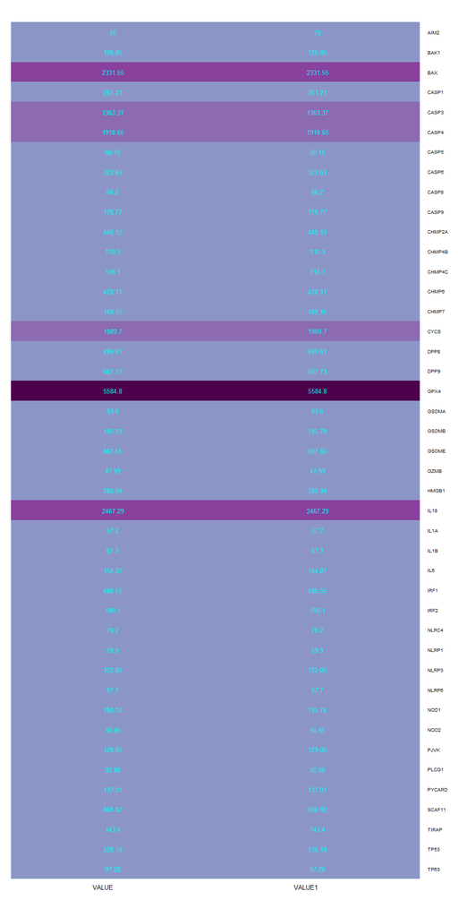

```r
tpm.df[["VALUE1"]] <- tpm.df[["VALUE"]]
tpm.matrix <- as.matrix(tpm.df)
heatmap.2(tpm.matrix,
  srtCol = 360,
  cellnote = tpm.matrix,
  dendrogram = "none", Colv = FALSE, Rowv = FALSE,
  col = brewer.pal(n = 9, name = "BuPu")[5:9], trace = "none", key = FALSE, lwid = c(0.1, 4), lhei = c(0.1, 4),
  cexCol = 1, cexRow = 0.75, symm = TRUE
)
```

[^1]: De La Salle University, Manila, Philippines, gonzales.markedward@gmail.com
[^2]: De La Salle University, Manila, Philippines, anish.shrestha@dlsu.edu.ph